# The Correlation Among The Prevalence of Mental Illness, Population Density, and Air Quality Using US States Data

## CMSC320 2022 Fall

# 1. Introduction

In modern society, physical injury has been greatly reduced due to the development of technology, but on the contrary, mental fatigue is increasing in contrast to material abundance. We are increasingly sensitive to stress and often under various psychological pressures. The cause of mental illness is usually still under research. Still, medical institutions generally define that an individual born with a particular vulnerability is caused by environmental stress and develops a mental illness.

Seoul is the sixth most population-dense city in the world. My family and friends have lived in Seoul or live and commute nearby, and everyone is concerned and complained about the "population density" in common. In addition, air pollution caused by fine dust tends to be remarkably serious in Seoul compared to other domestic cities. Therefore, I would like to see if population density and air quality affect mental health based on these experiences.

I considered the analysis using data from large cities worldwide, but I decided to use data analysis using state data from the United States. The United States is a coalition of several states, each with unique characteristics. Accurate analysis results will be expected because each state's population, environment, and land size are very diverse, and the country provides various data.

# 2. Data munging

The first step in my process will be to scour the web in search for the relevant data.Luckily I was able to find the 2019 Census US Population Data By State in Kaggle. United States Census Bureau (USCB) found land area data for each state, but USCB provides the data as a pdf file, so I created a .csv file to utilize the data.

## 2A Population and Land Area Data by State in United States

```python
import pandas as pd

state_pop_url = "https://raw.githubusercontent.com/MinJi-Kim710/Minji-Kim710.github.io/main/US_Population_Data_By_State_Lat_Long_2019.csv"
state_pop = pd.read_csv(state_pop_url)
state_pop.head()
```

|  | STATE | POPESTIMATE2019 | lat | long |
| --- | --- | --- | --- | --- |
| 0 | Alabama | 4903185 | 32.377716 | -86.300568 |
| 1 | Alaska | 731545 | 58.301598 | -134.420212 |
| 2 | Arizona | 7278717 | 33.448143 | -112.096962 |
| 3 | Arkansas | 3017804 | 34.746613 | -92.288986 |
| 4 | California | 39512223 | 38.576668 | -121.493629 |

```python
area_url = "https://raw.githubusercontent.com/MinJi-Kim710/Minji-Kim710.github.io/main/US_States_Land_Area.csv"
area = pd.read_csv(area_url)
area.head()
```

|  | state | area (square mi) |
| --- | --- | --- |
| 0 | Alabama | 52420 |
| 1 | Alaska | 665384 |
| 2 | Arizona | 113990 |
| 3 | Arkansas | 53179 |
| 4 | California | 163695 |

```python
area_and_pop = state_pop
area_and_pop["area (square mi)"] = area["area (square mi)"]
area_and_pop = area_and_pop.rename(columns = {'STATE': 'state', 'POPESTIMATE2019': 'population_2019', 'area (square mi)': 'area (square mi)'})

area_and_pop.head()
```

|  | state | population_2019 | lat | long | area (square mi) |
| --- | --- | --- | --- | --- | --- |
| 0 | Alabama | 4903185 | 32.377716 | -86.300568 | 52420 |
| 1 | Alaska | 731545 | 58.301598 | -134.420212 | 665384 |
| 2 | Arizona | 7278717 | 33.448143 | -112.096962 | 113990 |
| 3 | Arkansas | 3017804 | 34.746613 | -92.288986 | 53179 |
| 4 | California | 39512223 | 38.576668 | -121.493629 | 163695 |

## 2B Prevalence of Mental Illness Data

I think using the 2019 prevalence of mental illness data would increase the accuracy of this analysis. Covid-19 began in January 2020, and a study shows that the number of people suffering from mental disorders such as mental fatigue and depression increased due to the prolonged pandemic, so I think it is reasonable to find a connection with data from 2019 before COVID-19.

[MHA (Mental Health America)](https://mhanational.org/issues/2023/mental-health-america-prevalence-data) provides data on the Adult Prevalence of Any Mental Illness (AMI) and Youth with At Least One Major Depressive Episode (MDE) by the state in the United States. I created the .csv file because they provide the data as a report document.

```python
mental_url = "https://raw.githubusercontent.com/MinJi-Kim710/Minji-Kim710.github.io/main/US_Prevalence%20of%20Mental%20Illness%202019.csv"
mental = pd.read_csv(mental_url)
mental["total_patient"] = mental["Adults with Any Mental Illness"] + mental["Youth with At Least One Major Depressive Episode"]
mental.head()
```

|  | state | Adults with Any Mental Illness | Youth with At Least One Major Depressive Episode | total_patient |
| --- | --- | --- | --- | --- |
| 0 | Alabama | 737000 | 45000 | 782000 |
| 1 | Alaska | 107000 | 8000 | 115000 |
| 2 | Arizona | 944000 | 72000 | 1016000 |
| 3 | Arkansas | 464000 | 32000 | 496000 |
| 4 | California | 5419000 | 401000 | 5820000 |

## 2C Annual Air Quality by State

This data is the 2019 Annual Summary Data recorded by the United States Environmental Protection Agency (EPA) monitoring air quality in several counties in each state. I created an "avg_aqi" column by processing data to use each state's average air quality value.

In addition, I removed the row of Mexico, Puerto Rico, and the Virgin Islands since I only want to see 50 states in the United States.

```python
aqi_url = "https://raw.githubusercontent.com/MinJi-Kim710/Minji-Kim710.github.io/main/US_annual_aqi_by_county_2019.csv"
aqi_first = pd.read_csv(aqi_url)[["State", "Median AQI"]]

aqi_by_state_sum = aqi_first.groupby("State")["Median AQI"].sum()
aqi_by_state_count = aqi_first.groupby("State")["Median AQI"].count()

aqi = pd.DataFrame({"aqi_sum": aqi_by_state_sum, "count": aqi_by_state_count}).reset_index()
aqi["avg_aqi"] = aqi["aqi_sum"] / aqi["count"]

# remove the row of country of mexico, puerto rico, and virgin island
aqi = aqi.drop(index=[7,40,48]).reset_index()

aqi.head()
```

|  | index | State | aqi_sum | count | avg_aqi |
| --- | --- | --- | --- | --- | --- |
| 0 | 0 | Alabama | 667 | 17 | 39.235294 |
| 1 | 1 | Alaska | 173 | 9 | 19.222222 |
| 2 | 2 | Arizona | 544 | 13 | 41.846154 |
| 3 | 3 | Arkansas | 470 | 13 | 36.153846 |
| 4 | 4 | California | 2323 | 53 | 43.830189 |

# 3. Data Exploration and Analysis

## 3A Population In Area

I will use the population density ratio, so first, I have to check the population density by checking the number of people per unit area in the state.

However, Alaska and District of Columbia points are outliers, so the rest of the data is skewed to the left. Alaska has a very large land area but a significantly smaller population, while the District of Columbia has a vast population of 64 square miles of land area. Therefore, accurate data cannot be observed with a graph containing two values. I removed the two points and plotted the graph to observe the detailed chart.

```python
# drop thw row of Alaska and District of Columbia from area_and_pop dataframe
area_and_pop_revised = area_and_pop.drop(index=[1,8])
area_and_pop_revised = area_and_pop_revised.reset_index()
area_and_pop_revised = area_and_pop_revised.drop(columns='index')

# drop thw row of Alaska and District of Columbia from mental dataframe
mental_revised = mental.drop(index=[1,8])
mental_revised = mental_revised.reset_index()
mental_revised = mental_revised.drop(columns='index')

area_and_pop_revised.head()
```

|  | state | population_2019 | lat | long | area (square mi) |
| --- | --- | --- | --- | --- | --- |
| 0 | Alabama | 4903185 | 32.377716 | -86.300568 | 52420 |
| 1 | Arizona | 7278717 | 33.448143 | -112.096962 | 113990 |
| 2 | Arkansas | 3017804 | 34.746613 | -92.288986 | 53179 |
| 3 | California | 39512223 | 38.576668 | -121.493629 | 163695 |
| 4 | Colorado | 5758736 | 39.739227 | -104.984856 | 104094 |

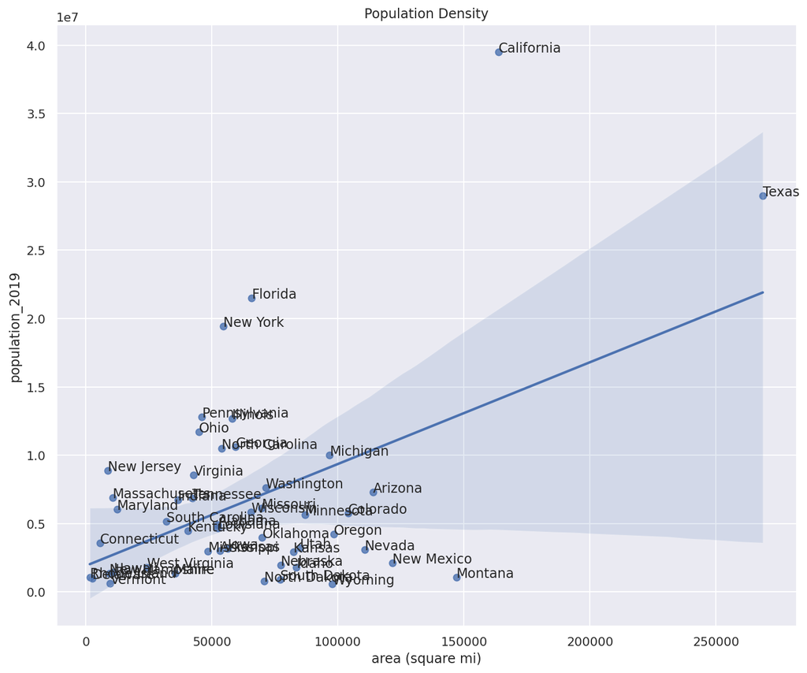

```python
import seaborn as sns
import matplotlib
import matplotlib.pyplot as plt

%config InlineBackend.figure_format = 'retina'
%matplotlib inline

# adjusting some plot display settings
matplotlib.rcParams['figure.figsize'] = [12, 10]
sns.set(color_codes=True)

# plotting population and land area
fig, ax = plt.subplots()
fig = sns.regplot(area_and_pop_revised["area (square mi)"], area_and_pop_revised["population_2019"], dropna=True)
plt.title("Population Density")

# labeling every point
for i, txt in enumerate(area_and_pop_revised['state']):
  ax.annotate(txt, (area_and_pop_revised["area (square mi)"][i], area_and_pop_revised["population_2019"][i]))
```

Despite removing two points, which are excessive outliers, both California and Texas are still bouncing. California and Texas seem to have a vast land area and a larger population than other states. However, this graph shows that the population of each state in the United States is generally similar in a similar size area.

## 3B Population Density VS Number of Mental Illness Patient

The regression model was plotted to confirm the correlation between population density and prevalence of mental illness.

First, I created the "population density" column dividing the population by land area.

```python
# calculating population density
area_and_pop_revised["population density"] = area_and_pop_revised["population_2019"] / area_and_pop_revised["area (square mi)"]
area_and_pop_revised.head()
```

|  | state | population_2019 | lat | long | area (square mi) | population density |
| --- | --- | --- | --- | --- | --- | --- |
| 0 | Alabama | 4903185 | 32.377716 | -86.300568 | 52420 | 93.536532 |
| 1 | Arizona | 7278717 | 33.448143 | -112.096962 | 113990 | 63.853996 |
| 2 | Arkansas | 3017804 | 34.746613 | -92.288986 | 53179 | 56.748040 |
| 3 | California | 39512223 | 38.576668 | -121.493629 | 163695 | 241.377092 |
| 4 | Colorado | 5758736 | 39.739227 | -104.984856 | 104094 | 55.322459 |

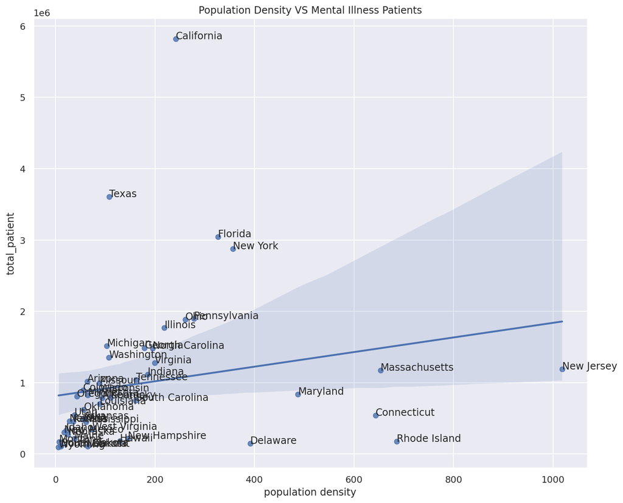

```python
# adjusting some plot display settings
matplotlib.rcParams['figure.figsize'] = [12, 10]
sns.set(color_codes=True)

# plotting population density
fig, ax = plt.subplots()  # exposing the fig and ax here so ax can be used to label
fig = sns.regplot(area_and_pop_revised["population density"], mental_revised["total_patient"], dropna=True)
plt.title("Population Density VS Mental Illness Patients")

# labeling every point
for i, txt in enumerate(area_and_pop_revised['state']):
  ax.annotate(txt, (area_and_pop_revised["population density"][i], mental_revised["total_patient"][i]))
```

This linear regression graph doesn't seem to show the correlation between population density and mental illness prevalence. A trend line has a positive correlation coefficient. Still, there are outliers like California and Texas, and the rest of the region looks generally close to the line, but it's not significantly clustered around the line.

## 3C Population Density VS Number of Mental Illness Patient - 2

This time, I draw a linear regression with variables on the x-axis as number of patients and variables on the y-axis as population density.

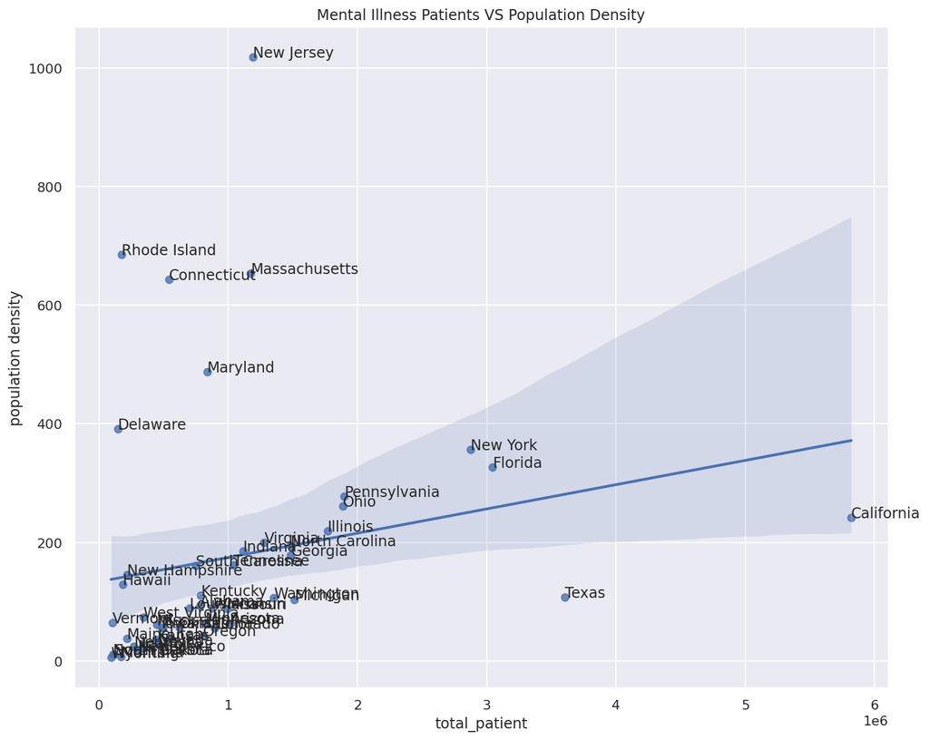

```python
# adjusting some plot display settings
matplotlib.rcParams['figure.figsize'] = [12, 10]
sns.set(color_codes=True)

# plotting population density
fig, ax = plt.subplots()  # exposing the fig and ax here so ax can be used to label
fig = sns.regplot(mental_revised["total_patient"], area_and_pop_revised["population density"], dropna=True)
plt.title("Mental Illness Patients VS Population Density")

# labeling every point
for i, txt in enumerate(area_and_pop_revised['state']):
  ax.annotate(txt, (mental_revised["total_patient"][i], area_and_pop_revised["population density"][i]))
```

I looked for something in common with New Jersey, Rhode Island, Connecticut, Massachusetts, Maryland, and Delaware to complement the six outliers.

## 3D Hypothesis

```python
# copying the area column
area_and_pop_revised["area_adjusted"] = area_and_pop_revised["area (square mi)"]

# # multiplying the states (New Jersey, Rhode Island, ) area by 2
area_and_pop_revised.loc[area_and_pop_revised["state"] == "New Jersey", "area_adjusted"] = area_and_pop_revised.loc[area_and_pop_revised["state"] == "New Jersey", "area_adjusted"] * 5
area_and_pop_revised.loc[area_and_pop_revised["state"] == "Rhode Island", "area_adjusted"] = area_and_pop_revised.loc[area_and_pop_revised["state"] == "Rhode Island", "area_adjusted"] * 5
area_and_pop_revised.loc[area_and_pop_revised["state"] == "Connecticut", "area_adjusted"] = area_and_pop_revised.loc[area_and_pop_revised["state"] == "Connecticut", "area_adjusted"] * 5
area_and_pop_revised.loc[area_and_pop_revised["state"] == "Massachusetts", "area_adjusted"] = area_and_pop_revised.loc[area_and_pop_revised["state"] == "Massachusetts", "area_adjusted"] * 5
area_and_pop_revised.loc[area_and_pop_revised["state"] == "Maryland", "area_adjusted"] = area_and_pop_revised.loc[area_and_pop_revised["state"] == "Maryland", "area_adjusted"] * 5
area_and_pop_revised.loc[area_and_pop_revised["state"] == "Delaware", "area_adjusted"] = area_and_pop_revised.loc[area_and_pop_revised["state"] == "Delaware", "area_adjusted"] * 5

area_and_pop_revised.head()
```

|  | state | population_2019 | lat | long | area (square mi) | population density | area_adjusted |
| --- | --- | --- | --- | --- | --- | --- | --- |
| 0 | Alabama | 4903185 | 32.377716 | -86.300568 | 52420 | 93.536532 | 52420 |
| 1 | Arizona | 7278717 | 33.448143 | -112.096962 | 113990 | 63.853996 | 113990 |
| 2 | Arkansas | 3017804 | 34.746613 | -92.288986 | 53179 | 56.748040 | 53179 |
| 3 | California | 39512223 | 38.576668 | -121.493629 | 163695 | 241.377092 | 163695 |
| 4 | Colorado | 5758736 | 39.739227 | -104.984856 | 104094 | 55.322459 | 104094 |

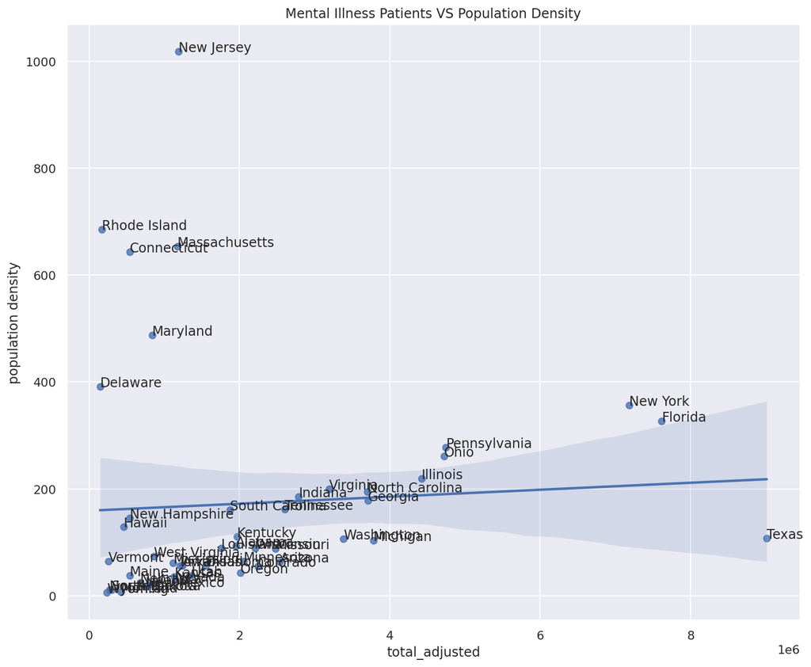

```python
# plotting population density
fig5, ax5 = plt.subplots()  # exposing the fig and ax here so ax can be used to label
fig5 = sns.regplot(mental_revised["total_adjusted"], area_and_pop_revised["population density"], dropna=True)
plt.title("Mental Illness Patients VS Population Density")

# labeling every point
for i, txt in enumerate(area_and_pop_revised['state']):
  ax5.annotate(txt, (mental_revised["total_adjusted"][i], area_and_pop_revised["population density"][i]))
```

## 3E Population Density vs. Air Quality

First, let's see if population density affects air quality.

Since District of Columbia is an outlier, I'll remove it and plot a linear regression.

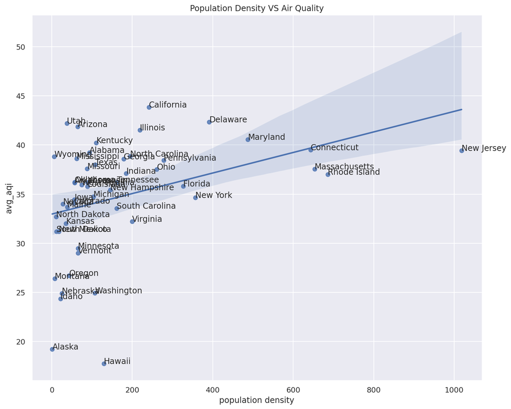

```python
# drop thw row of District of Columbia from area_and_pop dataframe
area_and_pop_revised = area_and_pop.drop(index=[8]).reset_index()
area_and_pop_revised = area_and_pop_revised.drop(columns='index')

# drop thw row of District of Columbia from aqi dataframe
aqi_revised = aqi.drop(index=[8]).reset_index()
aqi_revised = aqi_revised.drop(columns='index')

area_and_pop_revised

# calculating population density and aqi
area_and_pop_revised["population density"] = area_and_pop_revised["population_2019"]/area_and_pop_revised["area (square mi)"]

# graph
# plotting population density
fig3, ax3 = plt.subplots()  # exposing the fig and ax here so ax can be used to label
fig3 = sns.regplot(area_and_pop_revised["population density"], aqi_revised["avg_aqi"], dropna=True)
plt.title("Population Density VS Air Quality")

# labeling every point
for i, txt in enumerate(area_and_pop_revised['state']):
  ax3.annotate(txt, (area_and_pop_revised["population density"][i], aqi_revised["avg_aqi"][i]))
```

## 3F Air Quality vs. Mental Illness

Now I'll find out if air quality affects prevalance of mental Illness

[figure not shown]

```python
# plotting aqi vs. mental illness
fig4, ax4 = plt.subplots()  # exposing the fig and ax here so ax can be used to label
fig4 = sns.regplot(aqi["avg_aqi"], mental["total_patient"], dropna=True)
plt.title("Air Quality VS Average AQI")

# labeling every point
for i, txt in enumerate(area_and_pop_revised['state']):
  ax4.annotate(txt, (aqi["avg_aqi"][i], mental["total_patient"][i]))
```

# 4. Conclusion

I plotted and observed a linear regression graph to see if population density and atmospheric quality affect the prevalence of mental illness using 2019 mental illness prevalence, population density, and atmospheric quality data from states in the United States.

Although the graphs all have positive correlation coefficients, the distribution of scatterplots is often skewed to one side and generally showed no significant relationship. In particular, the correlation between population density and mental illness prevalence could hardly be confirmed.

All csv files used can be found at: https://github.com/MinJi-Kim710/Minji-Kim710.github.io